# Lab4

Author

Brandy Recio

### **1. Read in the data**

First download and then read in with `data.table::fread()`

```
Same dataset as lab3
```

```r
if (!file.exists("met_all.gz"))
  download.file(
    url = "https://raw.githubusercontent.com/USCbiostats/data-science-data/master/02_met/met_all.gz",
    destfile = "met_all.gz",
    method   = "libcurl",
    timeout  = 60
    )
met <- read.csv("met_all.gz")
```

### **2. Prepare the data**

```r
library(dplyr)
library(data.table)
library(lubridate)
setDT(met)
#remove temperatures less than -17C, and making sure there is no missing data in the key variables coded as 9999, 999, etc.
met <- met [temp > -17][elev == 9999.0, elev := NA]
#Generate a date variable using the funtions as.Date() (hint: you. will need the following to create a date paste (year, month,day,sep = "-"))
met[, week := week(as.Date(paste(year,month,day,sep = "-")))]
#using the data.table::week funtion, keep the observations of the firts week of the month.
met <- met[week == min(week, na.rm = TRUE)]
#compute the mean by station of the variables temp,rh, wind.sp, vis.dist,dew.point,lat,lon,and elev.
met_avg <- met[,.(temp=mean(temp,na.rm=TRUE), rh=mean(rh,na.rm=TRUE),
                  wind.sp=mean(wind.sp,na.rm=TRUE),
                  vis.dist=mean(vis.dist,na.rm=TRUE),
                  dew.point=mean(dew.point,na.rm=TRUE),
                  lat=mean(lat), lon=mean(lon),
                  elev=mean(elev,na.rm=TRUE)), by="USAFID"]

#Create a region variable for NW, SW, NE, SE based on lon = -98.00 and lat = 39.71 degrees
met_avg$region <- ifelse(met_avg$lon > -98 & met_avg$lat > 39.71, "northeast",
                         ifelse(met_avg$lon > -98 &
                                  met_avg$lat < 39.71, "southeast",
                                ifelse(met_avg$lon < -98 & met_avg$lat > 39.71,
                                       "northwest", "southwest")))
#create a categorical variable for elevation as in the lecture slides
met_avg$elev_cat <- ifelse(met_avg$elev > 252, "high", "low")

table(met_avg$region)
```

```
northeast northwest southeast southwest
      484       146       649       296
```

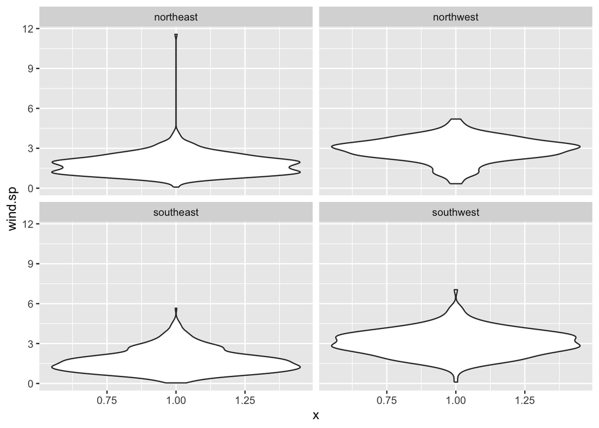

```r
library(ggplot2)
library(dplyr)   # for filter(), %>%, etc.

met_avg %>%
  filter(!(wind.sp %in% NA)) %>% #To make sure you deal with NAs
ggplot()+
  geom_violin(mapping = aes(y=wind.sp, x=1)) +
  facet_wrap(~region, nrow=2) #use facets
```

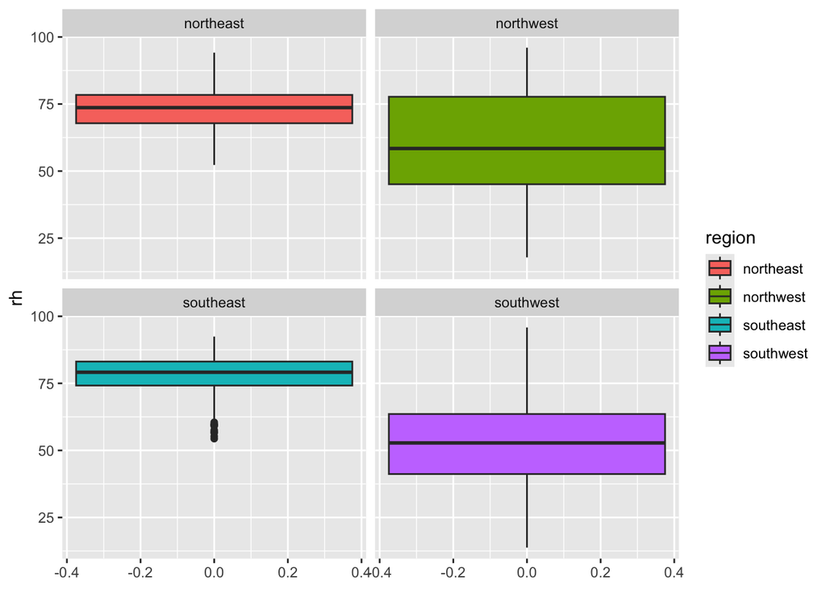

```r
met_avg %>%
  filter(!(region %in% NA)) %>%
ggplot() +
  geom_boxplot(mapping = aes(y=rh, fill=region)) +
  facet_wrap(~region, nrow=2)
```

### **4. Use `geom_point` with `stat_smooth` to examine the association between dew point and wind speed by region**

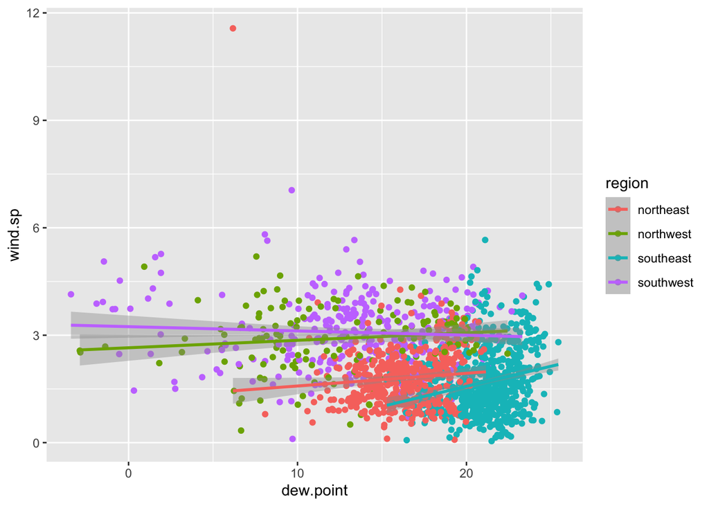

```r
met_avg %>%
  filter(!(dew.point %in% NA)) %>% #Make sure to deal with NAs
  ggplot(mapping = aes(x=dew.point, y=wind.sp, color=region)) + #color point by region
  geom_jitter() +
  stat_smooth(method=lm) #fit a linear regression line by region
```

### **5. Use `geom_bar` to create barplots of the weather stations by elevation category colored by region**

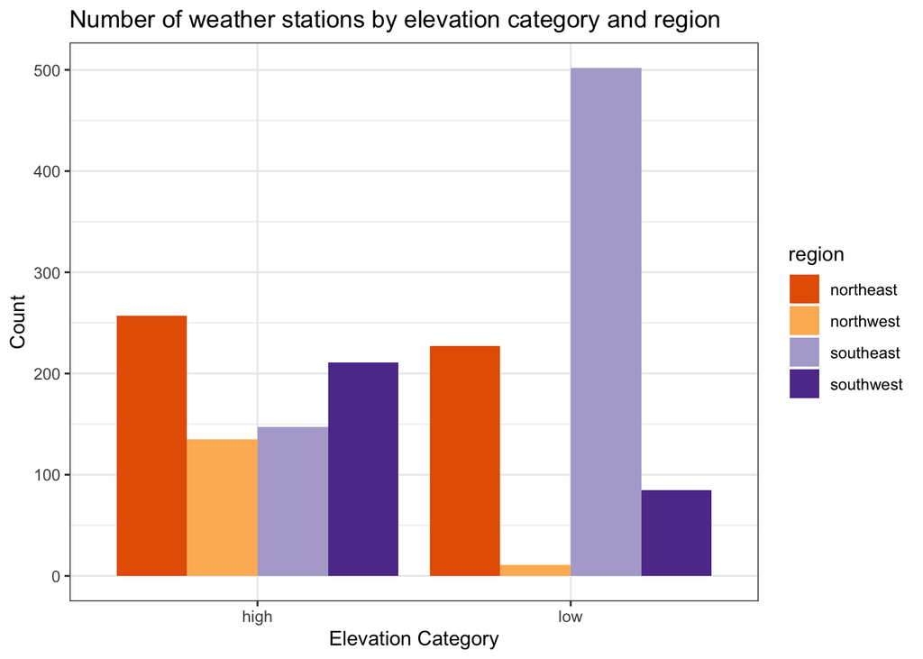

```r
met_avg %>%
  filter(!(elev_cat %in% NA)) %>%
  ggplot() +
  geom_bar(mapping=aes(x=elev_cat, fill=region), position = "dodge") +
  scale_fill_brewer(palette = "PuOr")+
  labs(title="Number of weather stations by elevation category and region",
       x="Elevation Category", y="Count") +
  theme_bw()
```

**Description:**

the bar chart reveals significant differences in weather station distribution across regions and elevation categories. The southeast has the highest number of stations overall, particularly concentrated at low elevations. the region northeast shows more stations at high elevations compared to the rest. The northwest has the fewest total stations.

### **6. Use `stat_summary` to examine mean dew point and wind speed by region with standard deviation error bars**

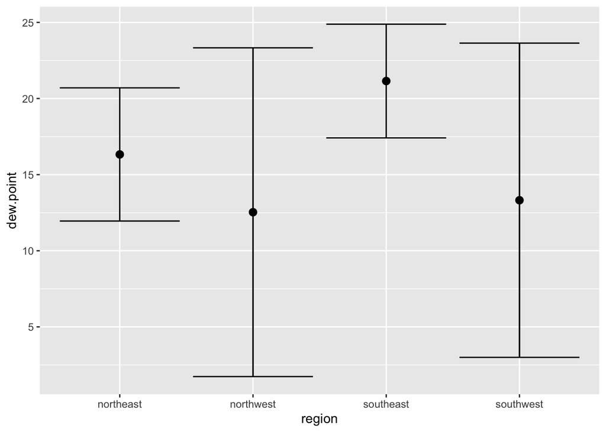

```r
met_avg %>%
  filter(!is.na(dew.point)& !is.na(wind.sp)) %>%
  ggplot(mapping=aes(x=region, y=dew.point)) +
  stat_summary(fun.data = "mean_sdl", geom="errorbar") +
  stat_summary(fun.data = "mean_sdl")
```

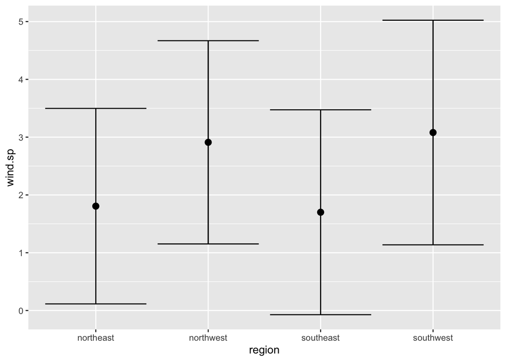

```r
met_avg %>%
  filter(!(region %in% NA)) %>%
  ggplot(mapping=aes(x=region, y=wind.sp)) +
  stat_summary(fun.data = "mean_sdl", geom = "errorbar") +
  stat_summary(fun.data = "mean_sdl")
```

**Description:**

The region with the highest mean dew point (approximately 21C) was southeast. The northwest region displays the lowest mean dew point around 12.5C. The error bars reveal that the is no significant difference between regions when they overlap.

### **7. Make a map showing the spatial trend in relative humidity in the US**

```r
library(data.table)
library(leaflet)

#Make sure to remove NAs
met_avg2 <- met_avg[!is.na(rh)]

#use addMarkers to include the top 10 places in relative humidity (hint: this is a useful rank (-rh) <= 10)

top10 <- met_avg2[rank(-rh) <= 10]

rh_pal = colorNumeric(c('blue','purple','red'), domain=met_avg2$rh) #Make a color palette with custom colors

leaflet(met_avg2) %>%
  addProviderTiles('OpenStreetMap') %>%
  addCircles (lat=~lat, lng=~lon, color=~rh_pal(rh),
              label=~paste0(round(rh,2), 'rh'), opacity=1, fillOpacity = 1, radius=500) %>%
  addMarkers(lat = ~lat, lng = ~lon, label = ~paste0(round(rh,2), 'rh'), data=top10) %>%
  addLegend('bottomleft', pal=rh_pal, values=met_avg2$rh,
            title="Relative humidity", opacity=1) #to add a legend
```

[interactive chart not shown]

**Description of the trend in RH across the U.S.**

The relative humidity map reveals a clear concentrated gradient across the US. The east region show more relative humidity values (around 80-90%), represented by color pink or red colors, the central regions display lower humidity, while the western regions exhibit again higher values. the top 10 highest relative humidity locations predominantly located in states of Florida, California, South Dakota, and Kentoky which reflects the influence of the sea or rivers.

### **8. Use a ggplot extension**

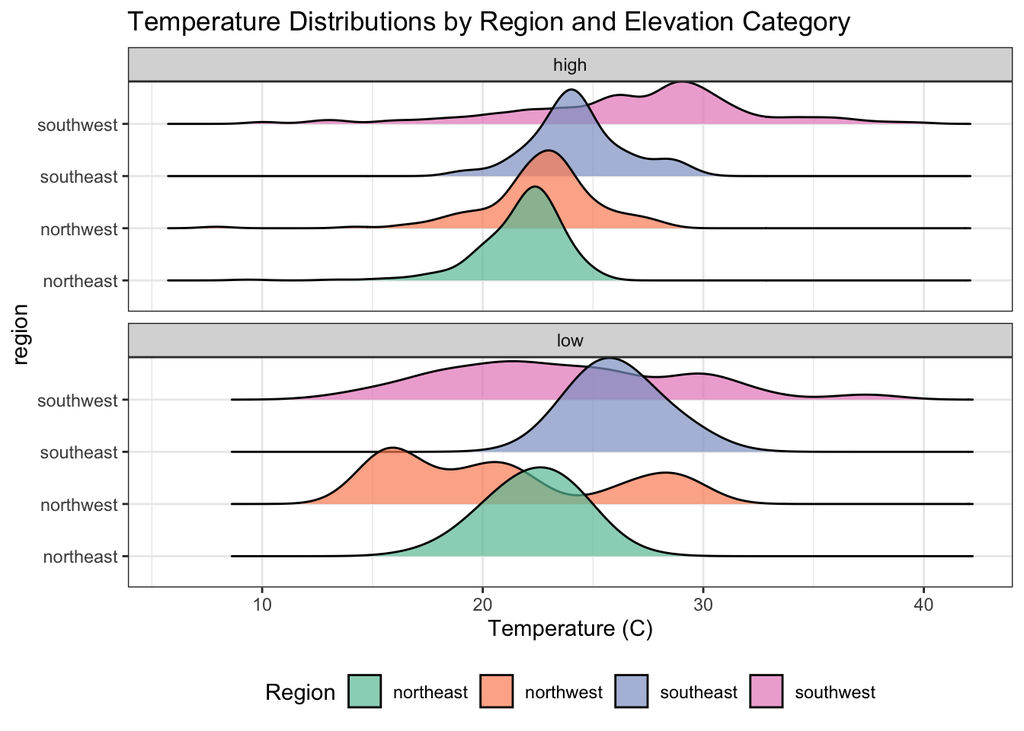

```r
library(ggridges)

met_avg %>%
  filter(!(region %in% NA)) %>%
  ggplot(mapping = aes(x = temp, y = region, fill = region)) +
  geom_density_ridges(alpha = 0.7) +
  facet_wrap(~elev_cat, nrow=2) + #create separate plot for each elevation category
  scale_fill_brewer(palette = "Set2") +
  labs(title= "Temperature Distributions by Region and Elevation Category",
       x= "Temperature (C)",
       Y= "Region",
       fill = "Region") +
  theme_bw()+
  theme(legend.position= "bottom")
```